# A3: SPL Library Checkouts

### Introduction

Sarah J. Maas is a internationally acclaimed author, known for writing the Throne of Glass and A Court of Thorns and Roses series. According to Goodreads, her books have sold more than twelve million copies worldwide. I started reading her books in middle school and they are some of my most favorite reads; I’ve read both previously mentioned series over and over, hoping to relive the immersive experience. I wanted to explore how Sarah J. Maas’s books have fluctuated in terms of popularity over the years. I was extremely curious whether they have increased or decreased in popularity since I read the books. To conduct this analysis, I will use data from the Seattle Public Library’s open data portal, specifically the data on all of books written by Sarah J. Maas.

### Summary Information

To gain a general understanding of the data, I found some summary values. All of the data is in relation to books written by Sarah J. Maas and checked out at the Seattle Public Library. The year with the lowest number of Sarah J. Maas checkouts is 2012 while the year with the highest number of checkouts is 2022. I was also interested in which type of material is most and least frequently checked out. EBOOK is the material type with the highest average checkouts while SOUNDDISC is the material type with the lowest average checkouts. The series with the most total checkouts is the A Court of Thorns and Roses Series while the series with the least total checkouts is the Crescent City Series. Similarly, the book with the most checkouts is *Throne of Glass* while the book with the least checkouts is *Kingdom of Ash*.

### The Dataset

- Who collected/published the data?

The data was collected by the [Seattle Public Library](https://data.seattle.gov/Community/Checkouts-by-Title/tmmm-ytt6) and published by the City of Seattle (City of Seattle).

- What are the parameters of the data (dates, number of checkouts, kinds of books, etc.)?

I filtered the data to include only books written by Sarah J. Maas. The “Creator” is listed as either “Sarah J. Maas” or “Maas, Sarah J.”. The dates range from August 2012 to January 2023. There are 3,223 rows and 12 columns. The columns are: UsageClass, CheckoutType, MaterialType, CheckoutYear, CheckoutMonth, Checkouts, Title, ISBN, Creator, Subjects, Publisher, and PublicationYear.

- How was the data collected or generated?

The data was generated using a monthly count of checkouts per physical and digital items from April 2005 to February 2023 at the Seattle Public Library. According the City of Seattle website, the checkout data comes from multiple current and historical sources. Usage data for media items is provided by Overdrive, hoopla, Freegal, and RBDigital. Physical item checkout data is provided by the Legrady artwork data archives and Horizon ILS.

- Why was the data collected?

The data was collected as a part of the City of Seattle’s Open Data program through which they aim to make data publicly available to city residents. The program seeks to improve public understanding of the City’s operations, generate economic opportunities, empower city employees, and encourage innovation. The data on checkouts can provide insights into management decisions and reading preferences.

- What, if any, ethical questions do you need to consider when working with this data?

While there are no obvious ethical questions, one that may come up is privacy. While the details of how the library obtained the checkout data is unclear, they may or may not have tracked or stored the specific individual accounts that checked out certain items. Still, since books can reveal a person’s interests, it can be considered a private affair.

- What are possible limitations or problems with this data? (at least 200 words)

One limitation with the data is a lack of consistency between different book titles and authors. For example, an author could be listed as both “First Last” or “Last, First”. This made filtering the data a bit difficult because I had to consider both cases. Similarly, the same titles were listed differently and in endless variations. This made it extremely difficult and tedious to run different analyses. To fix this, the data had to be cleaned up; otherwise, the results would be very unreliable. Another limitation is that the data only pertains to the Seattle Library’s checkout data. Seattle residents have their own interests, beliefs, and values which may or may not be reflected in the books they checkout and cannot be used to indicate the practices of other individuals in the state or country. This would limit the applicability of the findings to a wider audience since only a small, niche population is considered. Another limitation is that the specific checkout date is not listed. While the month and year are listed, the specific date is not which would make analyzing trends within a given month impossible. Lastly, the “Subjects” column is not comprehensive and consistent, with many different categories. This makes searching by subject a bit more difficult.

### Checkouts by Material Type

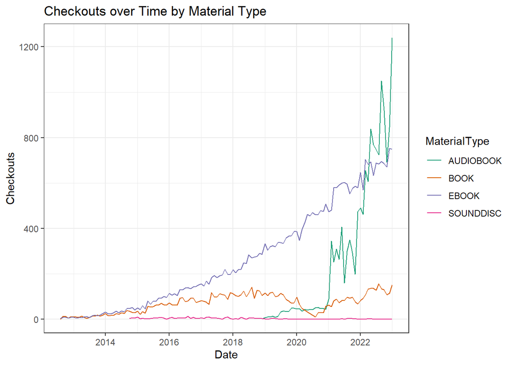

### Checkouts by Book in A Court of Thorns and Roses Series

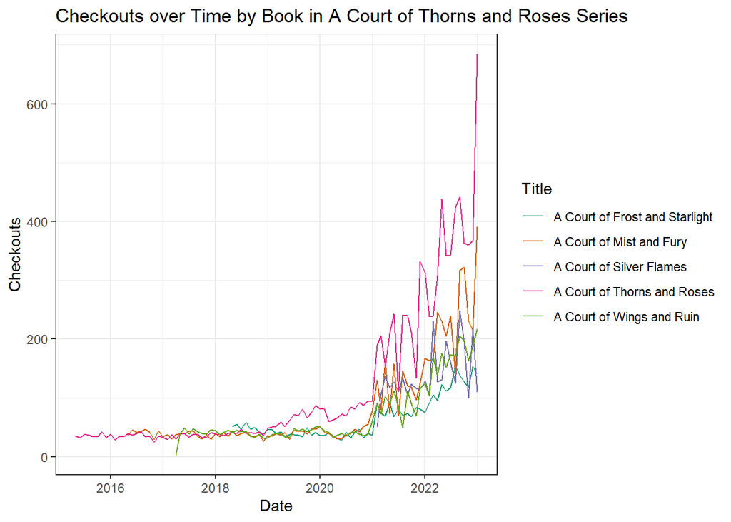

I measured the trends in the checkouts over time by books in the A Court of Thorns and Roses Series. I measured this for 2 reasons. Firstly, this is my favorite series by Sarah J. Maas and I was curious to see which books experienced surges of popularity. Secondly, after learning that this series has the highest total number of checkouts in my summary section, I became curious about which books contributed to this number the most and exactly when these checkouts occurred. The plot shows that until 2021, all of the books had a modest number of checkouts, however, in and after 2021, every book in the series experienced a huge surge in checkouts. This may be due to “booktok” or “bookstagram” which became popular during the pandemic and Maas’s books reached a wider audience. All throughout, *A Court of Thorns and Roses* seems to have the most checkouts while *A Court of Frost and Starlight* seems to have the least number of checkouts overall. One interesting pattern I noticed is that a surge and drop in one book generally corresponded to surges and drops in the other books. This suggests that people would checkout and read all the books in the series at or around the same time.

### Material Type for Each Series

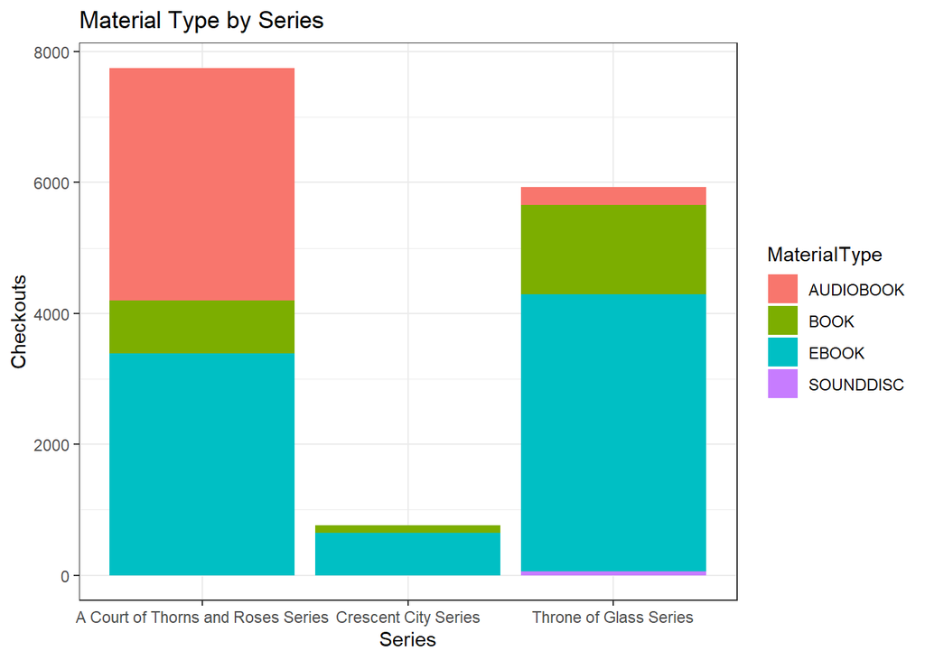

I measured the portion of checkouts for each material type for each series because I was curious to see whether readers preferred listening, reading digitally, or other forms for some series over others. Overall, the results were varied but eBooks are the most popular overall. For the A Court of Thorns and Roses series, audiobook is the most popular while book is the least popular. For the Throne of Glass series, eBook is the most popular while sound disc is the list. For the Crescent City series, eBook is the most popular while book is the least. However sound disc and audiobooks may not be available for the Crescent City series since it’s relatively new.

### References

Goodreads. (n.d.). Sarah J. Maas (author of a Court of Thorns and roses). Goodreads. Retrieved February 27, 2023, from https://www.goodreads.com/author/show/3433047.Sarah_J_Maas

Library, T. S. P. (2023, February 6). Checkouts by title: City of seattle open data portal. Seattle Open Data. Retrieved February 27, 2023, from https://data.seattle.gov/Community/Checkouts-by-Title/tmmm-ytt6